# Ejercicio 2

Efr?n Jim?nez Delgado

26 de julio de 2017

## An?lisis del Problema

El conjunto de datos corresponde a las ventas de un almac?n de ventas al por mayor. Analizar el patr?n de compras de sus clientes, le permitir?a al negocio segmentar sus clientes y preparar promociones o eventos especiales para cada grupo de clientes.

La ventaja que obtendr?a el negocio al hacer algo as? puede verse reflejada en un incremente en las ventas de los productos que caracterizan a cada uno de los clientes. Asimismo, el negocio podr?a planear mejor la forma en que distribuye su producto, pues si se encuentra un patr?n de consumo alto de un producto que es bajo en las otras zonas o grupos, se puede tomar la decisi?n de enviar mayores cantidades de ese producto a donde hay mayor consumo.

## Entendimiento de los Datos

El conjunto de datos contiene las siguientes variables:

- Channel: canal de venta (1 = Horeca - 298 observaciones, 2 = Retail - 142 observaciones).
- Region: regi?n en la cual se hizo la venta (1 = Lisboa - 77 observaciones, 2 = Oporto - 47 observaciones, 3 = Otra Regi?on - 316 observaciones).
- Fresh: cantidad de dinero en producto fresco.
- Grocery: cantidad de dinero en comestibles.
- Frozen: cantidad de dinero en alimento congelado.
- Detergents_Paper: cantidad de dinero en detergente.
- Delicassen: cantidad de dinero en delicatessen.

## Exploraci?n de los Datos

```r
#librer?as utilizadas
library(lattice)
library(reshape2)
```

```r
library(ggplot2)
library(qcc)
#establezca el directorio de trabajo
setwd("C://Universidad//TEC//2018//I Semestre//Open House//Comunidad//Taller 2")

#cargue el archivo a una variable que se llame ventas usando la funci?n read.csv
ventas <- read.csv('ventas.csv')

#sobreescriban las columnas Region y Channel con el factor de esa columna
ventas$Channel <- factor(ventas$Channel)
ventas$Region <- factor(ventas$Region)

#Utilice la funci?n str() para ver la estructura del conjunto de datos:
str(ventas)
```

```
## 'data.frame':    440 obs. of  8 variables:
##  $ Channel         : Factor w/ 2 levels "1","2": 2 2 2 1 2 2 2 2 1 2 ...
##  $ Region          : Factor w/ 3 levels "1","2","3": 3 3 3 3 3 3 3 3 3 3 ...
##  $ Fresh           : int  12669 7057 6353 13265 22615 9413 12126 7579 5963 6006 ...
##  $ Milk            : int  9656 9810 8808 1196 5410 8259 3199 4956 3648 11093 ...
##  $ Grocery         : int  7561 9568 7684 4221 7198 5126 6975 9426 6192 18881 ...
##  $ Frozen          : int  214 1762 2405 6404 3915 666 480 1669 425 1159 ...
##  $ Detergents_Paper: int  2674 3293 3516 507 1777 1795 3140 3321 1716 7425 ...
##  $ Delicassen      : int  1338 1776 7844 1788 5185 1451 545 2566 750 2098 ...
```

La mayor?a de las ventas se registraron en la regi?n #3 (otra regi?n), mientras que la mayor?a de las ventas se hicieron por medio del canal # 1 (Horeca), tal como se puede apreciar en los siguientes gr?ficos:

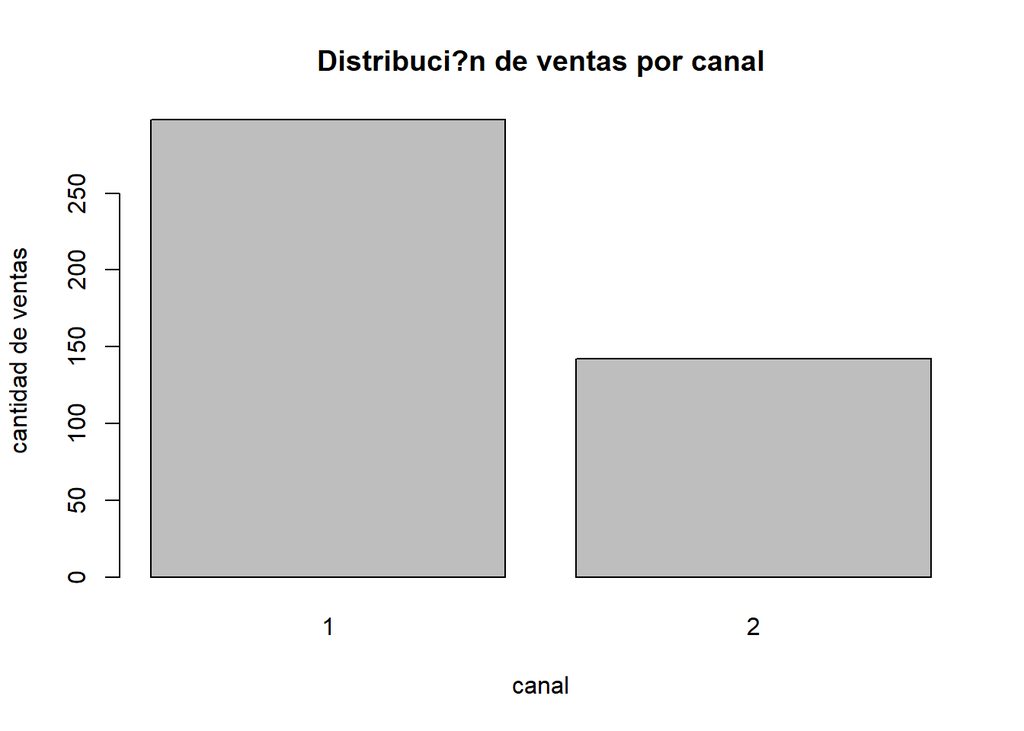

```r
barplot(table(ventas$Channel),
        main = 'Distribuci?n de ventas por canal',
        xlab = 'canal',
        ylab = 'cantidad de ventas')
```

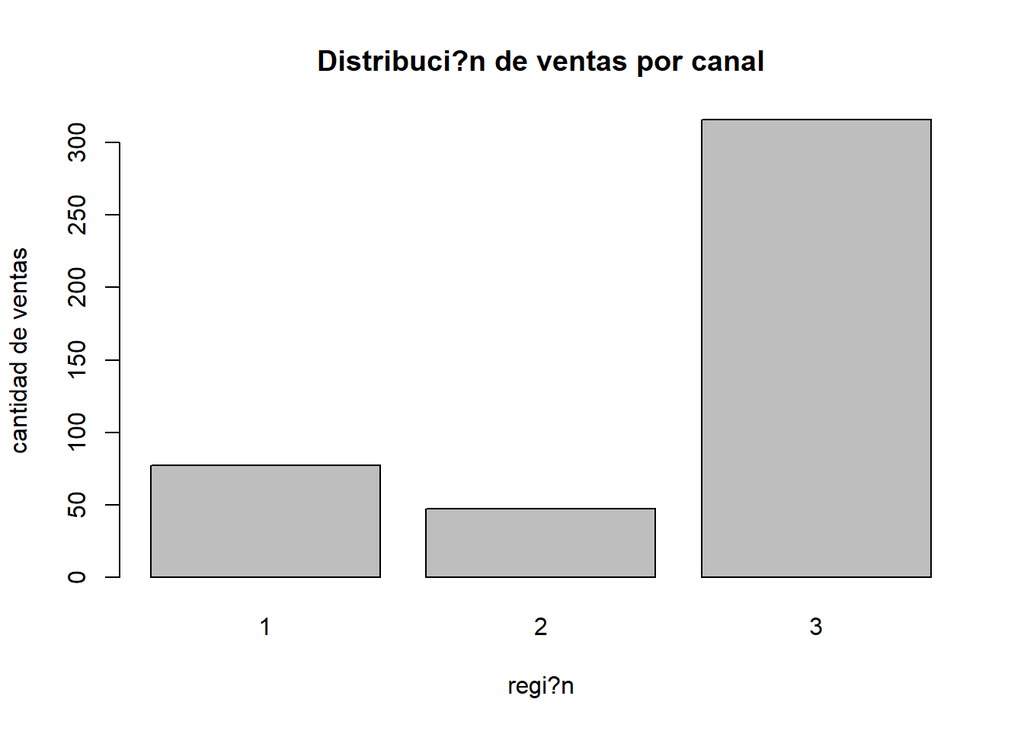

```r
barplot(table(ventas$Region),
        main = 'Distribuci?n de ventas por canal',
        xlab = 'regi?n',
        ylab = 'cantidad de ventas')
```

Si analizamos con mayor detalle la variable *Grocery*, su distribuci?n entre las regiones muestra que en todas las regiones la mayor?a de los clientes gastan poco, sin embargo esta proporci?n es mayor en la zona 1 y la zona 3. En la zona 2, cerca de un 50% de las observaciones gastan poco en comestibles, y hay un segundo ‘bloque’ o subconjunto que gasta m?s comparado con los otros grupos.

Tambi?n llama la atenci?n que hay un porcentaje de clientes, en la regi?n 2, que gastan bastante en comestibles. Esta proporci?n no se puede apreciar en las otras 2 regiones.

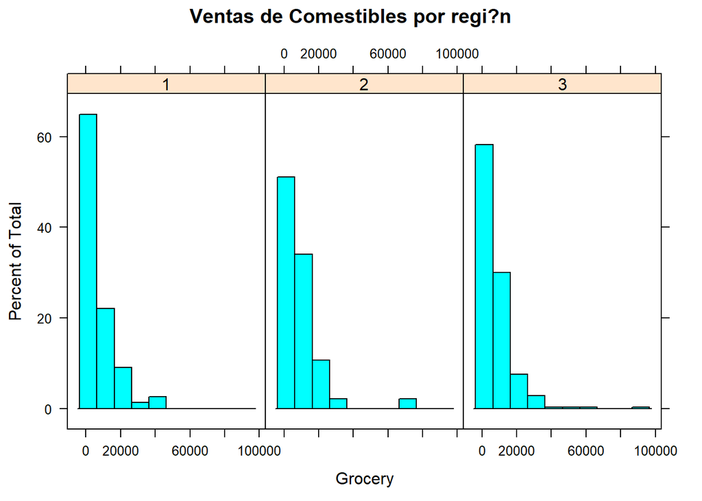

```r
#Utilicen el paquete lattice para crear un solo gr?fico, el cual contenga un histograma de Grocery por valor de la
#variable Channel

histogram(~Grocery | Region,
          data = ventas,
          main = 'Ventas de Comestibles por regi?n')
```

Al analizar la variable *Delicassen*, se puede observar que hay un patr?n de consumo muy bajo.Este patr?n no sorprender, pues se trata de ‘delicadezas’. Sin embargo, s? se puede apreciar una peque?a proporci?n de clientes que gastaron una cantidad significativa en la regi?n #3:

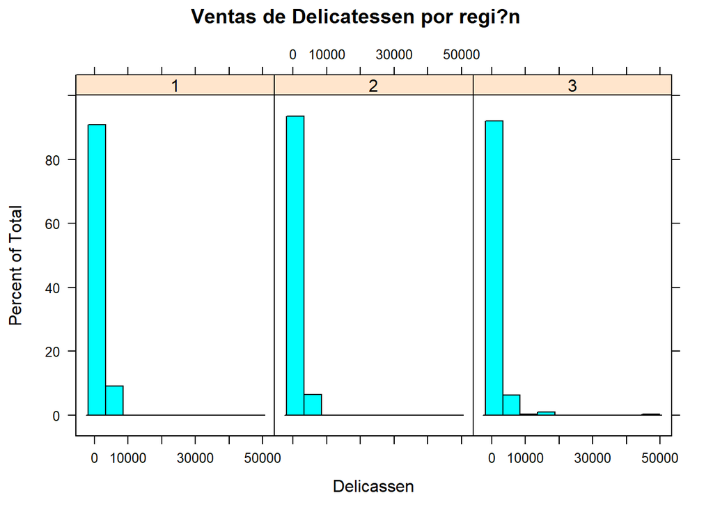

```r
#Utilicen el paquete lattice para crear un solo gr?fico, el cual contenga un histograma de Delicassen por valor de la
#variable Channel

histogram(~Delicassen | Region,
          data = ventas,
          main = 'Ventas de Delicatessen por regi?n')
```

Al hacer la comparaci?n de ventas por producto en cada uno de los canales, se puede apreciar algunas diferencias entre ellos. Por ejemplo, en el canal #2 hubo mayor consumo de detergentes, comestibles y l?cteos. Con respecto a productos frescos, en el canal #1 parece haber habido mayor consumo, aunque la diferencia no es tan marcada como en lo productos mencionados anteriormente.

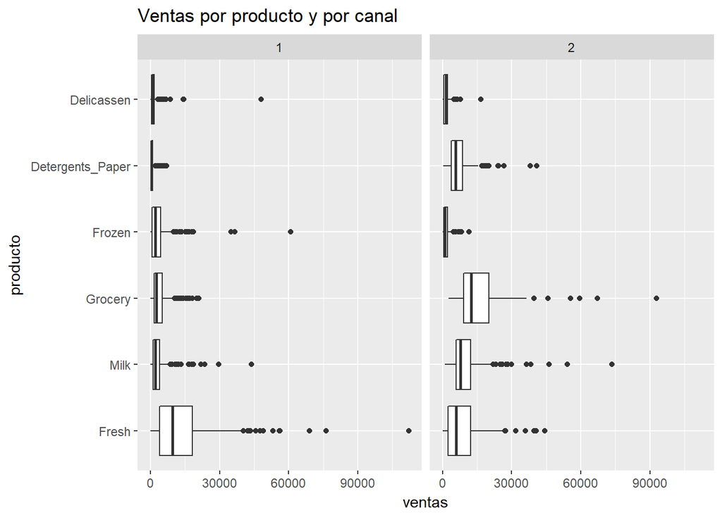

```r
#Utilicen el paquete ggplot para crear un solo gr?fico que les permita ver todas las variables cuantitativas en
#el contexto de la variable Channel
#pista: utilicen el paquete reshape2 y la funci?n melt para generar un conjunto de datos agrupable por la columna
#'variable' y en el eje y la variable 'value'.
#pista 2: utlicen la variable Channel como la faceta
#adicionalmente, inviertan los ejes para que las cajas se desplieguen horizontalmente
bxplt <- ggplot(data = melt(ventas), aes(x= variable, y = value))
bxplt <- bxplt + geom_boxplot()
bxplt <- bxplt + facet_wrap(~Channel)
bxplt <- bxplt + coord_flip()
bxplt <- bxplt + labs(x = 'producto', y  = 'ventas')
bxplt <- bxplt + ggtitle('Ventas por producto y por canal')
bxplt
```

## Modelo de Miner?a de Datos

Para agrupar a los clientes con base al consumo, vamos a utilizar solo las variables Fresh, Milk, Grocery, Frozen, Detergents_Paper y Delicassen. En este caso, vamos a intentar agrupar los clientes en 5 grupos diferentes.

```r
#crear el modelo (esto lo veremos en detalle luego, pero deber?a haber algunas partes de la sintaxis que ya entiendan)
#vamos a agrupar los clientes de acuerdo a las variables cuantitativas.
#Nota: arbitrariamente se van a crear 5 grupos. La cantidad de cl?steres debe ser mayormente una decisi?n del negocio,
#para la cual luego veremos como dar recomendaciones.
modelo.agrupacion <- kmeans(ventas[,c(3:8)], centers = 5)
```

Una vez creado el model, podemos asignar el cl?ster al cual pertenece cada observaci?n al conjunto de datos original.

```r
#predecir utilizando el modelo para agregar una variable nueva llamada 'cluster' al conjunto de datos
ventas$cluster <- modelo.agrupacion$cluster

#convertir la variable nueva a un factor
ventas$cluster <- factor(ventas$cluster)
```

## Evaluaci?n

Estos grupos grandes pueden representar al consumidor promedio, aquellos que no muestran patrones significativamente diferentes a los otros clientes.

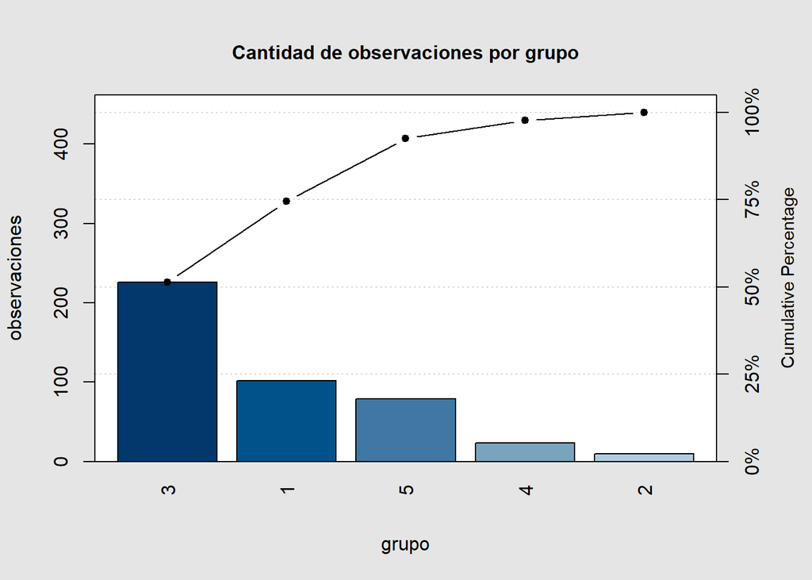

```
##
## Pareto chart analysis for table(ventas$cluster)
##      Frequency  Cum.Freq. Percentage Cum.Percent.
##   3 226.000000 226.000000  51.363636    51.363636
##   1 102.000000 328.000000  23.181818    74.545455
##   5  79.000000 407.000000  17.954545    92.500000
##   4  23.000000 430.000000   5.227273    97.727273
##   2  10.000000 440.000000   2.272727   100.000000
```

```r
#Utilizando el paquete qcc, cree un gr?fico Pareto para ver la distribuci?n de observaciones por cl?ster
#pista: refi?ranse a la presentaci?n del tema de estad?sticas descriptivas, diapositiva 41
pareto.chart(table(ventas$cluster),
             main = 'Cantidad de observaciones por grupo',
             xlab = 'grupo',
             ylab = 'observaciones')
```

Las principales caracter?sticas de cada grupo son:

- Principalmente observaciones de la regi?n 3 y el canal 1.
- Muy alto consumo de productos frescos.
- Bajo consumo de leche.
- Bajo consumo de comestibles.
- Alto consumo de alimentos congelados.
- Bajo consumo de detergentes.
- Bajo consumo de delicassen.

Grupo #3: (grupo m?s grande)

- Observaciones principalmente del canal 1 y la regi?n 3.
- Bajo consumo de productos frescos.
- Bajo consumo de leche.
- Muy bajo consumo de comestibles.
- Muy bajo consumo de alimentos congelados.
- Bajo consumo de detergentes.
- Muy bajo consumo de delicassen.

- Observaciones principalmente del canal 2 y la regi?n 3.
- Alto consumo de productos frescos.
- Muy alto consumo de leche.
- Muy alto consumo de comestibles.
- Alto consumo de alimentos congelados.
- Muy alto consumo de detergentes.
- Muy alto consumo de delicassen.

Grupo #5:

- Observaciones principalmente del canal 2 y la regi?n 3.
- Muy bajo consumo de productos frescos.
- Alto consumo de leche.
- Alto consumo de comestibles.
- Muy bajo consumo de alimentos congelados.
- Alto consumo de detergentes.
- Bajo consumo de delicassen.

```r
#utilizando la funci?n by, aplique la funci?n summary() al conjunto de datos 'ventas'
#pista: by(conjunto de datos, columna por la cual dividir, summary)
by(ventas, ventas$cluster, summary)
```

```
## ventas$cluster: 1
##  Channel Region     Fresh            Milk          Grocery
##  1:81    1:18   Min.   :11314   Min.   :  134   Min.   :    3
##  2:21    2:11   1st Qu.:17202   1st Qu.: 1497   1st Qu.: 2078
##          3:73   Median :19981   Median : 3078   Median : 3822
##                 Mean   :21338   Mean   : 3934   Mean   : 5176
##                 3rd Qu.:25169   3rd Qu.: 5319   3rd Qu.: 7278
##                 Max.   :34454   Max.   :16687   Max.   :21042
##      Frozen      Detergents_Paper   Delicassen      cluster
##  Min.   :  118   Min.   :   3.0   Min.   :   57.0   1:102
##  1st Qu.: 1061   1st Qu.: 244.5   1st Qu.:  623.2   2:  0
##  Median : 2548   Median : 499.5   Median : 1160.5   3:  0
##  Mean   : 4183   Mean   :1138.1   Mean   : 1713.0   4:  0
##  3rd Qu.: 5274   3rd Qu.:1435.8   3rd Qu.: 2306.8   5:  0
##  Max.   :35009   Max.   :6707.0   Max.   :14472.0
## --------------------------------------------------------
## ventas$cluster: 2
##  Channel Region     Fresh            Milk          Grocery
##  1:1     1:1    Min.   :   85   Min.   : 4980   Min.   :20170
##  2:9     2:1    1st Qu.: 9928   1st Qu.:27686   1st Qu.:32054
##          3:8    Median :19521   Median :37396   Median :42761
##                 Mean   :21264   Mean   :37443   Mean   :46711
##                 3rd Qu.:33550   3rd Qu.:45635   3rd Qu.:58591
##                 Max.   :44466   Max.   :73498   Max.   :92780
##      Frozen        Detergents_Paper   Delicassen    cluster
##  Min.   :   36.0   Min.   :  239    Min.   :  903   1: 0
##  1st Qu.:  996.8   1st Qu.:19032    1st Qu.: 1572   2:10
##  Median : 3243.0   Median :22121    Median : 2907   3: 0
##  Mean   : 6287.2   Mean   :21699    Mean   : 8743   4: 0
##  3rd Qu.: 5049.5   3rd Qu.:26084    3rd Qu.: 6131   5: 0
##  Max.   :36534.0   Max.   :40827    Max.   :47943
## --------------------------------------------------------
## ventas$cluster: 3
##  Channel Region      Fresh            Milk          Grocery
##  1:188   1: 41   Min.   :    3   Min.   :   55   Min.   :  137
##  2: 38   2: 23   1st Qu.: 2624   1st Qu.: 1114   1st Qu.: 1766
##          3:162   Median : 5996   Median : 2362   Median : 3027
##                  Mean   : 6144   Mean   : 3277   Mean   : 4115
##                  3rd Qu.: 9406   3rd Qu.: 4887   3rd Qu.: 6110
##                  Max.   :14276   Max.   :18664   Max.   :12822
```

[output cut: 24 more lines]

```
## ventas$cluster: 5
##  Channel Region     Fresh            Milk          Grocery
##  1: 7    1:14   Min.   :   18   Min.   : 1275   Min.   : 8852
##  2:72    2:11   1st Qu.: 1090   1st Qu.: 7742   1st Qu.:13498
##          3:54   Median : 3136   Median :10765   Median :16709
##                 Mean   : 4668   Mean   :11639   Mean   :18290
##                 3rd Qu.: 5994   3rd Qu.:13692   3rd Qu.:22069
##                 Max.   :22039   Max.   :29892   Max.   :36486
##      Frozen        Detergents_Paper   Delicassen     cluster
##  Min.   :   25.0   Min.   :  241    Min.   :   3.0   1: 0
##  1st Qu.:  417.5   1st Qu.: 5967    1st Qu.: 609.5   2: 0
##  Median :  959.0   Median : 7015    Median :1265.0   3: 0
##  Mean   : 1525.2   Mean   : 8060    Mean   :1594.5   4: 0
##  3rd Qu.: 1962.5   3rd Qu.: 9721    3rd Qu.:2089.0   5:79
##  Max.   :10155.0   Max.   :18594    Max.   :6372.0
```

## Resultados

El algoritmo de miner?a de datos utilizado pudo encontrar caracter?sticas muy espec?ficas para dividir a los clientes, y formar grupos interesantes para el negocio. Debido a la gran cantidad de obervaciones de la regi?n 3, esta variable no result? muy importante, pues en todos los grupos hay una mayor?a de observaciones de esta regi?n. Con respecto al canal, sin embargo, se pudieron defininer 3 grupos donde hay m?s que nada observaciones del canal 1 y 2 grupos donde el canal 2 es mayor?a.

Con respecto al consumo de diferentes productos, varios de los grupos identificados tienen caracter?sticas predominantes, ya sea montos de consumo muy alto o muy bajo, lo cual puede ser muy ?til para el negocio a la hora de pensar en promociones especiales en diferentes tipos de productos (puede ayudar a saber d?nde van a ser m?s efectivas dichas promociones.)